# Improving quantitative and computational skills: practical advice (for graduate students (?))

14 April 2016

## general advice

- "are my stats answering my scientific question?"
- "is there something simpler I can do that will still answer the question adequately"? (Murtaugh, 2007)
- use what the people around you use
- … but not if they're wrong (if you can help it)
- experimental design \(\gg\) statistics
- systematic error \(\gg\) random error
- understand *as much as you can* about your methods

## computation

## learn about reproducibility

- learn some [data carpentry](http://www.datacarpentry.org/) ([workshop @ UF last year](http://reproducible-science-curriculum.github.io/2015-06-01-reproducible-science-idigbio/))
- transparency for scientific, career-enhancement, ethical, political (FOIA/ClimateGate) … reasons
- "future you" is your most important collaborator

Resources:

- [Jenny Bryan's notes](https://stat545-ubc.github.io/)
- [more notes](https://github.com/bbolker/iiscvisit/blob/master/workshops/repro_research.pdf)
- [R. Fitzjohn: reproducible research in the R ecosystem](https://github.com/richfitz/reproducibility-2014)

## ask good questions ("how not to get flamed on the R list")

- do your homework
- create a *minimal reproducible example*
- give enough context  
  (avoid "X-Y problems")
- be careful about "bugs" and "crashes" (call them "infelicities" instead)

[figure not shown]

[the Allium](http://www.theallium.com/engineering/computer-programming-to-be-officially-renamed-googling-stackoverflow/)

## give back to the community

- cite software
- report bugs (as much detail as possible)
- make suggestions
- help others

## trusting R packages

- how long has the package been around?
- is there an associated peer-reviewed paper?
- who wrote it?
- how widely used is it?
- does it have a vignette?
- is the documentation any good?
- does it have tests?

## toolboxes

- JAGS/BUGS, AD Model Builder, Template Model Builder, Stan …
- power tools!
- freedom from many constraints
- fit almost any model, whether it's sensible or not … (Lavine, 2010)

–

> I never blamed the Hole Hawg; I blamed myself. The Hole Hawg is dangerous because it does exactly what you tell it to. It is not bound by the physical limitations that are inherent in a cheap drill, and neither is it limited by safety interlocks that might be built into a homeowner's product by a liability-conscious manufacturer. The danger lies not in the machine itself but in the user's failure to envision the full consequences of the instructions he gives to it …

Neal Stephenson, ["In the beginning was the command line"](http://www.cryptonomicon.com/beginning.html)

Beware: MCMC sampling can be dangerous! [WinBUGS manual](http://www.mrc-bsu.cam.ac.uk/wp-content/uploads/manual14.pdf)

## statistics

## learn about p-hacking

- **exploration**
- **confirmation**  
  (hypothesis testing, most model selection)
- **prediction** …

be honest!

- pre-register your analyses, at least informally
- don't select and then confirm! (the gospel of the "minimal adequate model")

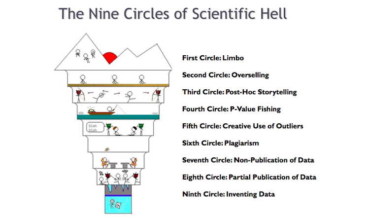

http://imgur.com/gallery/jyHgk

## read (some of) these

[figure not shown]

[figure not shown]

[figure not shown]

## prioritize

- pick **at most** two of the following:
  - big data
  - structure  
    (phylogenetic, spatial, temporal, general blocking)
  - non-Normal distributions  
    (binomial, Poisson < zero-inflated, ordinal < censored …)
  - observation/occupancy modeling
  - multi-causality (structural equation models)
- try to ignore the rest (null hypothesis tests)

## learn some likelihood

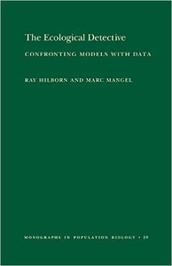

[figure not shown]

[figure not shown]

## learn some linear algebra

- focus on concepts and geometry
- analogies with scalar analogues, e.g.  
  \((\mathbf x- \boldsymbol\mu) \mathbf V^{-1} (\mathbf x- \boldsymbol\mu)^\top \approx (x-\mu)^2/\sigma^2\)
- biological meanings of mathematical objects
- e.g. eigenvectors …
  - stable age distribution
  - combination of environmental properties
  - combination of morphometric measurements
- mostly ignore computational details
- *sparse* matrices

## learn about linear models

- \(\mathbf y \sim \textrm{Normal}(\mathbf X \boldsymbol \beta)\)
- *model matrix* \(\mathbf X\) captures contrasts among categories, interactions among variables, more
- underpins most practical statistical models
- many extensions (generalized, mixed, additive …)
- component of more complex (nonlinear/hierarchical/survival) models

## further resources

- Crome (1997)
- Hurlbert (1984) : also Oksanen (2001), Cottenie & De Meester (2003)
- Hobbs & Hooten (2015)

## alternative title

**Computational ecology: state-of the-science, challenges and opportunities**

- mixed models and extensions
- models for animal movement: putting the pieces together
- new toolboxes for hierarchical computation
- (machine learning algorithms)
- penalization, shrinkage, and mixed models (Dahlgren, 2010)
- complex models: model misspecification and overfitting
- estimation for nonlinear time series

## References

Cottenie, K., & De Meester, L. (2003). Comment to Oksanen (2001): Reconciling Oksanen (2001) and Hurlbert (1984). *Oikos*, *100*(2), 394–396.

Crome, F. H. J. (1997). Researching tropical forest fragmentation: Shall we keep on doing what we’re doing? In W. F. Laurance & R. O. Bierregard (Eds.), *Tropical forest remnants: Ecology, management, and conservation of fragmented communities* (pp. 485–501). Chicago, IL: University of Chicago Press.

Dahlgren, J. P. (2010). Alternative regression methods are not considered in Murtaugh (2009) or by ecologists in general. *Ecology Letters*, *13*(5), E7–E9. http://doi.org/10.1111/j.1461-0248.2010.01460.x

Hobbs, N. T., & Hooten, M. B. (2015). *Bayesian Models: A Statistical Primer for Ecologists*. Princeton, New Jersey: Princeton University Press.

Hurlbert, S. H. (1984). Pseudoreplication and the design of ecological field experiments. *Ecological Monographs*, *54*(2), 187–211. http://doi.org/10.2307/1942661

Lavine, M. (2010). Living dangerously with big fancy models. *Ecology*, *91*(12), 3487–3487. http://doi.org/10.1890/10-1124.1

Murtaugh, P. A. (2007). Simplicity and Complexity in Ecological Data Analysis. *Ecology*, *88*(1), 56–62. Retrieved from http://www.esajournals.org/doi/abs/10.1890/0012-9658%282007%2988%5B56%3ASACIED%5D2.0.CO%3B2

Oksanen, L. (2001). Logic of Experiments in Ecology: Is Pseudoreplication a Pseudoissue? *Oikos*, *94*(1), 27–38. Retrieved from http://www.jstor.org.lp.hscl.ufl.edu/stable/3547252